# Data 605 HW8

William Jasmine

2023-03-16

Questions come from [“Introduction to Probability”](https://math.dartmouth.edu/~prob/prob/prob.pdf) by Charles M. Grinstead.

# Question 11, Section 7.2

## Problem Description

A company buys 100 lightbulbs, each of which has an exponential lifetime of 1000 hours. What is the expected time for the first of these bulbs to burn out? (See Exercise 10.)

## Solution

It’s first helpful to actually solve question 10, which asks: “Let $X_1, X_2,..., X_n$ be $n$ independent random variables each of which has an exponential density with mean $µ$. Let M be the minimum value of the $X_j$ . Show that the density for $M$ is exponential with mean $µ/n$. Hint: Use cumulative distribution functions.”

We define $M$ as the minimum of our random variables: $M = \text{min}(X_1, X_2,..., X_n)$. The probability that $M$ is less than some sample value $m$ would then be equal to the probability that any of random variables are less than $m$:

$$P(M \leq m) = P(X_1 \leq m \cup X_2 \leq m \cup \text{... } \cup X_n
< m)$$

Taking the complement of this statement (1 minus the probability that all the random variables are greater than $m$), we get that:

$$P(M \leq m) = 1 - P(X_1 \geq m \cap X_2 \geq m \cap \text{... } \cap X_n
\geq m)$$

Using the fact that all of the $X$s are independent, we can rewrite the second term of the above using a product of probabilities:

$$P(M \leq m) = 1 - P(X_1 \geq m)P(X_2 \geq m)...P(X_n < m)$$

We know that the cumulative distribution function of a random variable $X$ is equal to $P(X \geq x) = \int_x^{\infty} f_X(x) dx$ where $f_X(x)$ represents the probability density function of $X$. Using the fact that each of our $X$s have exponential probability density, we can write:

$$\begin{align}
P(X \geq x) &= \int_x^{\infty} f_X(x) \\
P(X \geq x) &= \int_x^{\infty} \lambda e^{-\lambda x} dx \\
P(X \geq x) &= -e^{-\lambda x}|_x^{\infty} \\
P(X \geq x) &= 0 - (-e^{-\lambda x}) \\
P(X \geq x) &= e^{-\lambda x} \\
\end{align}$$

Plugging this result back into our previous equation, we have:

$$\begin{align}
P(M \leq m) &= 1 - (e^{-\lambda m}) (e^{-\lambda m})...(e^{-\lambda
m}) \text{ , repeated } n \text{ times.} \\
P(M \leq m) &= 1 - (e^{-\lambda m})^n \\
P(M \leq m) &= 1 - e^{-\lambda mn}
\end{align}$$

Taking the derivative of the above returns the PDF, $f_M(m)$:

$$\begin{align}
f_M(m) &= \frac{d}{dx} (1 - e^{-\lambda mn}) \\
f_M(m) &= 0 - (-\lambda n e^{-\lambda m n} \\
f_M(m) &= \lambda n e^{-\lambda m n} \\
\end{align}$$

If we define $\Lambda = \lambda n$, then $f_M(m)$ is an exponential PDF with mean $\mu_M = \frac{1}{\Lambda}$. Thus:

$$\begin{align}
\mu_M &= \frac{1}{\lambda n} \\
\mu_M &= \frac{1}{\frac{1}{\mu}n} \\
\mu_M &= \frac{\mu}{n}
\end{align}$$

We can now use the above results to actually solve the question at hand. In this scenario we have 100 light bulbs ($n= 100$) that each last for 1,000 hours ($\mu = 1,000$). $\mu_M$ in this case represents the amount of time we can expect to pass before the first light bulb breaks, and thus:

$$\mu_M = \frac{\mu}{n} = \frac{1000}{100} = 10$$

In other words, we can expect the first light bulb to break after 10 hours.

## Empirical Testing

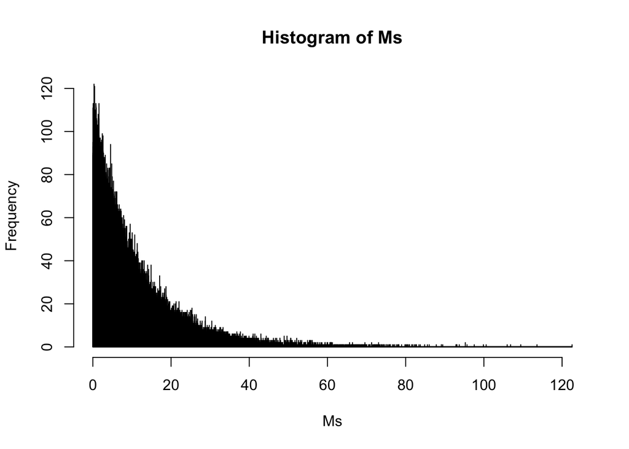

```r
set.seed(1234)

sims <- 100000
n <- 100
mu <- 1000
l <- 1 / mu
Ms <- c()

for (i in 1:sims){
  Xs <- log(1 - runif(n)) / (-l)
  Ms[i] <- min(Xs)
}

hist(Ms, breaks=10000)
```

A histogram of the results is provided above, and we see that taking the average value from each simulation results in a number very close to 10:

```r
mean(Ms)
```

```
## [1] 10.00657
```